# Power Analysis

Maira Andrade

2023-07-10

```r
# Load R Packages
library(MASS); library(lme4); library(car); library(lmerTest); library(tidyverse); library(afex); library(car); library(emmeans); library(effsize); library(ez); library(FSA); library(MBESS); library(effectsize); library(boot); library(dplyr); library(mvtnorm); library(gridExtra); library(reshape2); library(pwr); library(pwr2ppl); library(lsr); library(viridis); library(broom); library(Superpower); library(MBESS); library(grid); library(GGally); library(scales); library(here) ; library(data.table); library(Matrix); library(kableExtra); library(knitr)
```

# 1. G*Power & SuperPower

- “Calculating power for factorial designs is not accurate in GPower. A **[blog post](https://approachingblog.wordpress.com/2018/01/24/powering-your-interaction-2/)** by Roger Giner-Sorolla explains why GPower drastically underestimates the sample you would need to power an interaction. In order to adequately power interaction effects, you ideally need to simulate your experiment. This means you would program the effect sizes you are expecting across multiple factors and see how many times it would return a significant result if you repeated it many times. This cannot be done in GPower, so it would require you to learn a programming language like R” (Bartlett, 2022)
- “SuperPower simulates data and allows users to correct for multiple comparisons in exploratory ANOVA designs, and automatically provides the statistical power for all main effects, interactions, and simple comparisons for a specified ANOVA design. The **[online manual](http://arcaldwell49.github.io/SuperpowerBook)** (Caldwell et al., 2022) provides detailed examples for power analyses (ranging from One-Way ANOVA designs to three-way interactions for mixed designs, MANOVA analyses, and power analyses for when ANOVA assumptions are violated)” (Lakens & Caldwell, 2019).

**References**

1. Bartlett, J. (2022). Introduction to Power Analysis. https://doi.org/10.17605/OSF.IO/PCFVJ
2. Caldwell, A. R., Lakens, D., Parlett-Pelleriti, C. M., Prochilo, G., & Aust, F. (2022). Power Analysis with Superpower. https://aaroncaldwell.us/SuperpowerBook/index.html#preface
3. Lakens, D., & Caldwell, A. R. (2019). Simulation-Based Power-Analysis for Factorial ANOVA Designs [Preprint]. PsyArXiv. https://doi.org/10.31234/osf.io/baxsf

# 2. SuperPower

“Currently the ANOVA_design function can create designs with up to three factors, for both within, between, and mixed designs. It requires the following input: design, n, mu, sd, r, and optionally allows you to set labelnames.

**design**: string that specifies the design.

**n**: the sample size for each between subject condition. Can be specified as a single value (when all conditions have the same sample size), or as a vector of values specifying the sample size for each condition.

**mu**: a vector with the means for each condition.

**sd**: the population standard deviation. Assumes homogeneity of variances (only one standard deviation can be provided). Can be specified as a single value (when all conditions have the same standard deviation), or as a vector of values specifying the standard deviation for each condition.

**r**: the correlation(s) for within designs (or 0 for between designs). Can be specified as a single value (when all pairs of variables have the same correlation), or as a correlation matrix specifying the correlation between each pair.

**labelnames**: This is an optional vector of words that indicates factor names and level names.

A final optional setting is to specify if you want to automatically print a plot or not (plot = TRUE or FALSE)” (Caldwell et al., 2022)

**References**

1. Caldwell, A. R., Lakens, D., Parlett-Pelleriti, C. M., Prochilo, G., & Aust, F. (2022). Chapter 2 The Experimental Design | Power Analysis with Superpower. https://aaroncaldwell.us/SuperpowerBook/the-experimental-design.html

# 3. Original Study

```r
# Load Original Study Data
wide.dt <- read.csv("wide.dt.csv")
```

**Means** by Diagnostic Group Across Conditions

| Diagnosis | Risk.Adv_Gain | Risk.Adv_Loss | Risk.Disadv_Gain | Risk.Disadv_Loss |
| --- | --- | --- | --- | --- |
| Control | 4.35 | 4.26 | 1.67 | 1.29 |
| Diagnosed ADHD | 4.7 | 4.16 | 2.25 | 1.45 |
| Undiagnosed ADHD | 4.61 | 4.3 | 3.03 | 2.69 |

**Standard Deviations** by Diagnostic Group Across Conditions

| Diagnosis | Risk.Adv_Gain | Risk.Adv_Loss | Risk.Disadv_Gain | Risk.Disadv_Loss |
| --- | --- | --- | --- | --- |
| Control | 1.91 | 1.8 | 1.95 | 1.75 |
| Diagnosed ADHD | 1.71 | 2.14 | 2.03 | 1.84 |
| Undiagnosed ADHD | 1.44 | 1.72 | 1.99 | 1.78 |

**Correlations**

```r
# Split the data by Group and compute correlation matrices
cor_list <- wide.dt %>%
  split(.$Diagnosis) %>%
  lapply(function(wide.dt) cor(wide.dt[ ,c("Risk.Adv_Gain", "Risk.Adv_Loss", "Risk.Disadv_Gain", "Risk.Disadv_Loss")]))
# Combine correlation matrices into a block diagonal matrix
r_matrix <- bdiag(cor_list[[1]], cor_list[[2]], cor_list[[3]])
```

The output below shows the correlations between conditions for each diagnostic group:

**Control [1:4]**

**Diagnosed ADHD [5:8]**

**Undiagnosed ADHD [9:12]**

*From left to right*: RA_Gain, RA_Loss, RD_Gain, RD_Loss.

```r
round(r_matrix, 2)
```

```
## 12 x 12 sparse Matrix of class "dsCMatrix"
##
##  [1,] 1.00 0.65 0.34 0.36 .     .     .     .     .     .    .     .
##  [2,] 0.65 1.00 0.16 0.31 .     .     .     .     .     .    .     .
##  [3,] 0.34 0.16 1.00 0.64 .     .     .     .     .     .    .     .
##  [4,] 0.36 0.31 0.64 1.00 .     .     .     .     .     .    .     .
##  [5,] .    .    .    .    1.00  0.39  0.19  0.22  .     .    .     .
##  [6,] .    .    .    .    0.39  1.00 -0.25 -0.05  .     .    .     .
##  [7,] .    .    .    .    0.19 -0.25  1.00  0.55  .     .    .     .
##  [8,] .    .    .    .    0.22 -0.05  0.55  1.00  .     .    .     .
##  [9,] .    .    .    .    .     .     .     .     1.00  0.36 0.34 -0.02
## [10,] .    .    .    .    .     .     .     .     0.36  1.00 0.20 -0.18
## [11,] .    .    .    .    .     .     .     .     0.34  0.20 1.00  0.00
## [12,] .    .    .    .    .     .     .     .    -0.02 -0.18 0.00  1.00
```

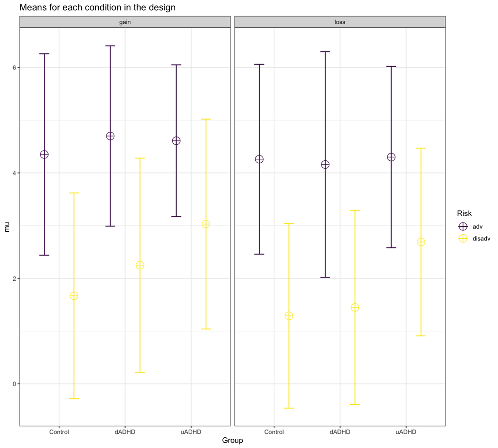

```r
# Plotting Results
```

# 4. Power Calculation (Simulations Parameters)

**design**: Same as original Study - ‘3x2x2’

**n**: Because this is a mixed design I could only input one ‘n’ for all groups. For this reason I decided to divide the original study’s total sample by 3 to get a balanced sample. **n=28**.

**mu**: Mean differences were estimated based on effect sizes reported by our original study, Dekkers et al., 2016 (meta-analysis), Dekkers et al., 2021 and Roberts et al., 2021 (meta-analysis). I attempted to stay as close to the original study as possible by only altering the means where necessary for each hypothesis.

**sd**: values remained the same as the original study for the simulations

**r**: values remained the same as the original study for the simulations

**Effect Sizes**

Group:Risk interaction (ANOVA)

- Dekkers et al., (2021): **0.07 (Partial eta-squared)**
- Original study (2023): **0.07 (Partial eta-squared)**

Pairwise comparisons - Diagnosed ADHD vs. Control (t-test)

Risk is advantageous (dADHD - Control)

- Dekkers et al., 2021: **0.32 (Cohen’s d)**

Risk is disadvantageous (dADHD - Control)

- Dekkers et al., 2016 (Meta-analysis): **-0.37 (Cohen’s d)**
- Roberts et al., 2021 (Meta-analysis): **-0.36 (Cohen’s d)**
- Dekkers et al., 2021: **-0.21 (Cohen’s d)**

**Desired Power:** 80%

**Alpha Level:** 0.05

**Number of simulations for each design:**

```r
nsims = 2000
```

# 5. Hypothesis 1

The **diagnosed and undiagnosed ADHD groups** will choose the **risky option less often** than **controls** when **risk is advantageous** *and* make **more risky choices** than the **control group** when the **risk is disadvantageous**.

### 5.1. Sample (n=28)

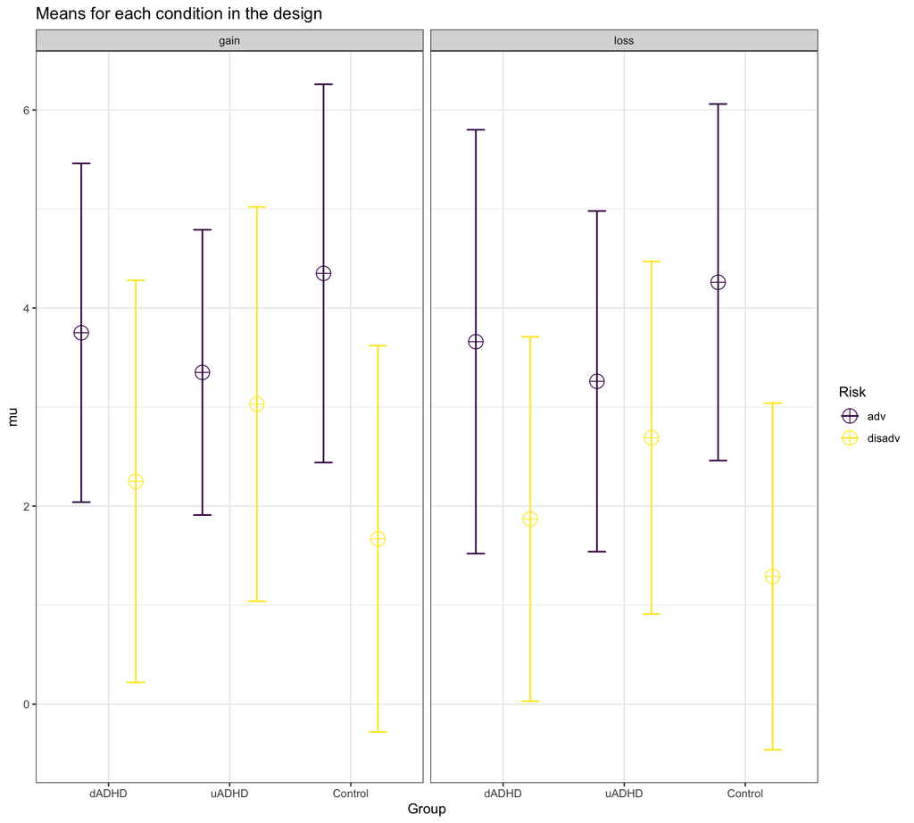

```r
#Plot
H1 <- ANOVA_design(design = "3b*2w*2w",
                   n = 28,
                   mu = c(3.75,3.66,2.25,1.87,
                          3.35,3.26,3.03,2.69,
                          4.35,4.26,1.67,1.29),
                   sd = c(1.71, 2.14, 2.03, 1.84,
                          1.44, 1.72, 1.99, 1.78,
                          1.91, 1.80, 1.95, 1.75),
                   r = r_matrix,
                   labelnames = c("Group", "dADHD", "uADHD", "Control", "Risk", "adv", "disadv", "Domain", "gain", "loss"),
                   plot = TRUE
)
```

```r
# Run 2000 simulations
H1pwr <- ANOVA_power(H1,
                        alpha_level = 0.05,
                        nsims = nsims,
                        verbose = FALSE)
```

Power and Effect sizes for ANOVA tests

| comparison | power | partial_eta_squared | cohen_f | non_centrality |
| --- | --- | --- | --- | --- |
| Group | 8.700459 | 0.0059694 | 0.0774937 | 0.4864277 |
| Risk | 99.999998 | 0.4129869 | 0.8387726 | 56.9866915 |
| Group:Risk | 98.209719 | 0.1983681 | 0.4974488 | 20.0438801 |
| Domain | 29.335071 | 0.0246991 | 0.1591369 | 2.0512892 |
| Group:Domain | 5.025258 | 0.0000432 | 0.0065709 | 0.0034973 |
| Risk:Domain | 16.052904 | 0.0115290 | 0.1079975 | 0.9447395 |
| Group:Risk:Domain | 5.031697 | 0.0000542 | 0.0073606 | 0.0043884 |

Power and Effect sizes for pairwise comparisons (t-tests) - Risk is Advantageous

|  | comparison | power | effect_size |
| --- | --- | --- | --- |
| 8 | p_Group_dADHD_Risk_adv_Domain_gain_Group_Control_Risk_adv_Domain_gain | 22.75 | 0.3399362 |
| 19 | p_Group_dADHD_Risk_adv_Domain_loss_Group_Control_Risk_adv_Domain_loss | 19.05 | 0.3074750 |
| 42 | p_Group_uADHD_Risk_adv_Domain_gain_Group_Control_Risk_adv_Domain_gain | 57.90 | 0.5952062 |
| 49 | p_Group_uADHD_Risk_adv_Domain_loss_Group_Control_Risk_adv_Domain_loss | 54.55 | 0.5731115 |

Power and Effect sizes for pairwise comparisons (t-tests) - Risk is Disadvantageous

|  | comparison | power | effect_size |
| --- | --- | --- | --- |
| 29 | p_Group_dADHD_Risk_disadv_Domain_gain_Group_Control_Risk_disadv_Domain_gain | 17.80 | -0.2862398 |
| 38 | p_Group_dADHD_Risk_disadv_Domain_loss_Group_Control_Risk_disadv_Domain_loss | 20.75 | -0.3192049 |
| 55 | p_Group_uADHD_Risk_disadv_Domain_gain_Group_Control_Risk_disadv_Domain_gain | 70.55 | -0.6934866 |
| 60 | p_Group_uADHD_Risk_disadv_Domain_loss_Group_Control_Risk_disadv_Domain_loss | 82.15 | -0.8038927 |

### 5.2. Sample (n=160)

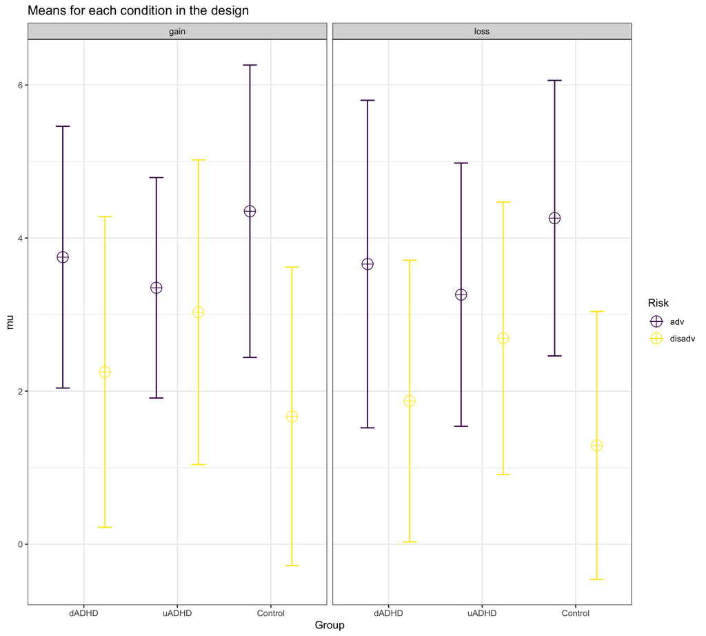

```r
#Plot
H1 <- ANOVA_design(design = "3b*2w*2w",
                   n = 160,
                   mu = c(3.75,3.66,2.25,1.87,
                          3.35,3.26,3.03,2.69,
                          4.35,4.26,1.67,1.29),
                   sd = c(1.71, 2.14, 2.03, 1.84,
                          1.44, 1.72, 1.99, 1.78,
                          1.91, 1.80, 1.95, 1.75),
                   r = r_matrix,
                   labelnames = c("Group", "dADHD", "uADHD", "Control", "Risk", "adv", "disadv", "Domain", "gain", "loss"),
                   plot = TRUE
)
```

```r
# Run 2000 simulations
H1pwr <- ANOVA_power(H1,
                        alpha_level = 0.05,
                        nsims = nsims,
                        verbose = FALSE)
```

Power and Effect sizes for ANOVA tests

| comparison | power | partial_eta_squared | cohen_f | non_centrality |
| --- | --- | --- | --- | --- |
| Group | 29.872031 | 0.0057935 | 0.0763363 | 2.7795870 |
| Risk | 100.000000 | 0.4057098 | 0.8262444 | 325.6382373 |
| Group:Risk | 100.000000 | 0.1936254 | 0.4900187 | 114.5364575 |
| Domain | 92.741765 | 0.0239843 | 0.1567600 | 11.7216526 |
| Group:Domain | 5.149102 | 0.0000419 | 0.0064728 | 0.0199847 |
| Risk:Domain | 64.014668 | 0.0111910 | 0.1063844 | 5.3985115 |
| Group:Risk:Domain | 5.187208 | 0.0000526 | 0.0072506 | 0.0250766 |

Power and Effect sizes for pairwise comparisons (t-tests) - Risk is Advantageous

|  | comparison | power | effect_size |
| --- | --- | --- | --- |
| 8 | p_Group_dADHD_Risk_adv_Domain_gain_Group_Control_Risk_adv_Domain_gain | 84.40 | 0.3326814 |
| 19 | p_Group_dADHD_Risk_adv_Domain_loss_Group_Control_Risk_adv_Domain_loss | 78.05 | 0.3048534 |
| 42 | p_Group_uADHD_Risk_adv_Domain_gain_Group_Control_Risk_adv_Domain_gain | 99.95 | 0.5939115 |
| 49 | p_Group_uADHD_Risk_adv_Domain_loss_Group_Control_Risk_adv_Domain_loss | 99.90 | 0.5708446 |

Power and Effect sizes for pairwise comparisons (t-tests) - Risk is Disadvantageous

|  | comparison | power | effect_size |
| --- | --- | --- | --- |
| 29 | p_Group_dADHD_Risk_disadv_Domain_gain_Group_Control_Risk_disadv_Domain_gain | 74.85 | -0.2927503 |
| 38 | p_Group_dADHD_Risk_disadv_Domain_loss_Group_Control_Risk_disadv_Domain_loss | 82.55 | -0.3244361 |
| 55 | p_Group_uADHD_Risk_disadv_Domain_gain_Group_Control_Risk_disadv_Domain_gain | 100.00 | -0.6897638 |
| 60 | p_Group_uADHD_Risk_disadv_Domain_loss_Group_Control_Risk_disadv_Domain_loss | 100.00 | -0.7970911 |

### 5.3. Summary

For the uADHD-Control comparisons I was much less conservative based on our findings where we found large effects.

# 6. Hypothesis 2a & 2b

**2a**: The **diagnosed and undiagnosed ADHD groups** will make **more risky choices** than the **control group only** when the **risk is disadvantageous**, and make a higher or equal number of risky choices when the risk is advantageous.

**2b**: The **undiagnosed ADHD** group will make **more risky choices** than both the **diagnosed ADHD and control groups** when the **risk is disadvantageous**.

### 6.1. Sample (n=28)

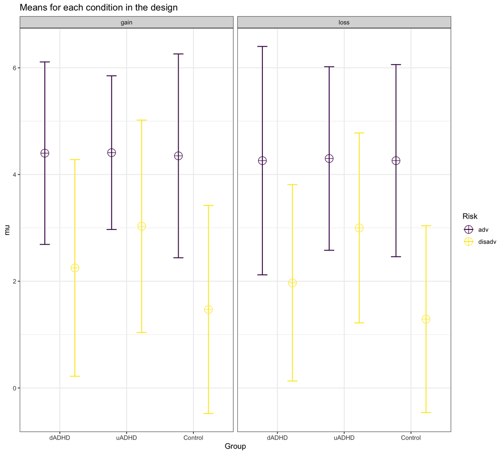

```r
#Plot
H2ab <- ANOVA_design(design = "3b*2w*2w",
                   n = 28,
                   mu = c(4.40,4.26,2.25,1.97,
                            4.41,4.30,3.03,3.00,
                            4.35,4.26,1.47,1.29),
                   sd = c(1.71, 2.14, 2.03, 1.84,
                          1.44, 1.72, 1.99, 1.78,
                          1.91, 1.80, 1.95, 1.75),
                   r = r_matrix,
                   labelnames = c("Group", "dADHD", "uADHD", "Control", "Risk", "adv", "disadv", "Domain", "gain", "loss"),
                   plot = TRUE
)
```

```r
# Run 2000 simulations
H2pwr <- ANOVA_power(H2ab,
                        alpha_level = 0.05,
                        nsims = nsims,
                        verbose = FALSE)
```

Power and Effect sizes for ANOVA tests

| comparison | power | partial_eta_squared | cohen_f | non_centrality |
| --- | --- | --- | --- | --- |
| Group | 62.604779 | 0.0776702 | 0.2901911 | 6.8210795 |
| Risk | 100.000000 | 0.5505192 | 1.1067019 | 99.2079237 |
| Group:Risk | 75.046801 | 0.0992554 | 0.3319527 | 8.9255987 |
| Domain | 13.753918 | 0.0092096 | 0.0964114 | 0.7529081 |
| Group:Domain | 5.943464 | 0.0015869 | 0.0398679 | 0.1287452 |
| Risk:Domain | 5.345884 | 0.0003808 | 0.0195176 | 0.0308559 |
| Group:Risk:Domain | 5.800202 | 0.0013492 | 0.0367567 | 0.1094356 |

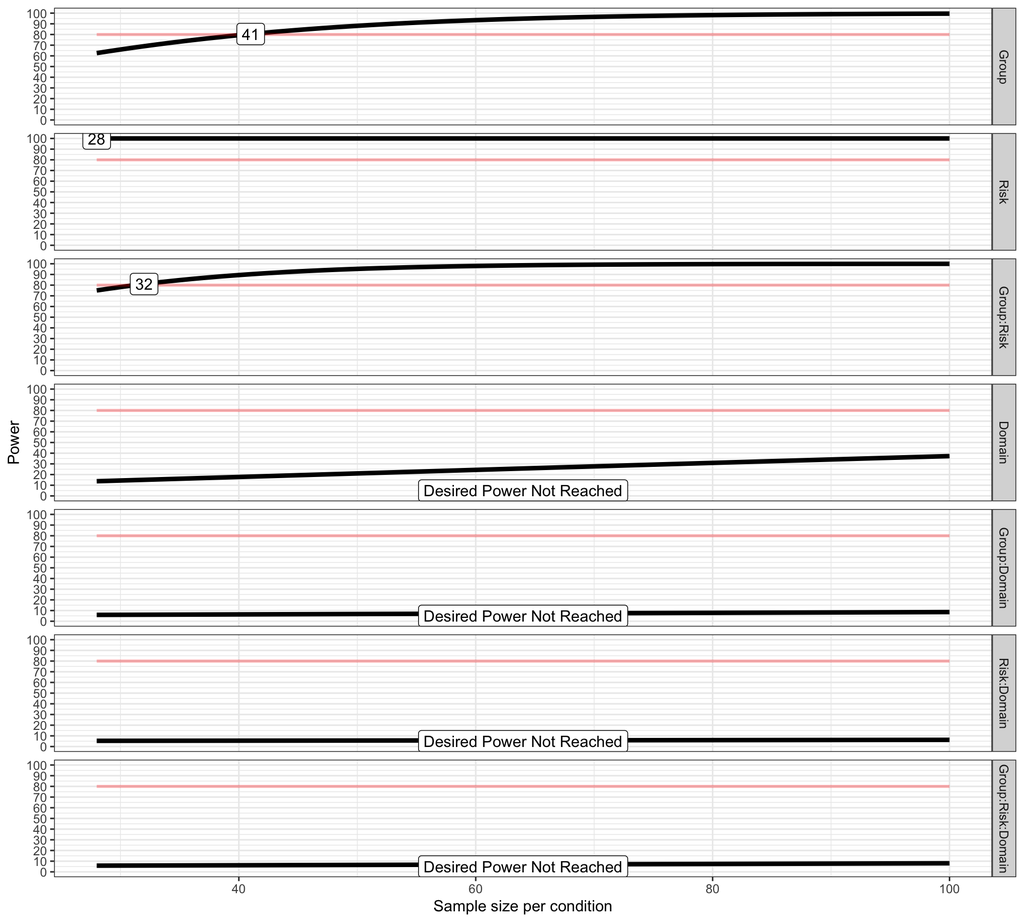

Power and Effect sizes for pairwise comparisons (t-tests) - Risk is Disadvantageous

|  | comparison | power | effect_size |
| --- | --- | --- | --- |
| 29 | p_Group_dADHD_Risk_disadv_Domain_gain_Group_Control_Risk_disadv_Domain_gain | 29.90 | -0.3921861 |
| 34 | p_Group_dADHD_Risk_disadv_Domain_loss_Group_uADHD_Risk_disadv_Domain_loss | 55.00 | 0.5771063 |
| 38 | p_Group_dADHD_Risk_disadv_Domain_loss_Group_Control_Risk_disadv_Domain_loss | 28.55 | -0.3822569 |
| 55 | p_Group_uADHD_Risk_disadv_Domain_gain_Group_Control_Risk_disadv_Domain_gain | 83.85 | -0.8089488 |
| 60 | p_Group_uADHD_Risk_disadv_Domain_loss_Group_Control_Risk_disadv_Domain_loss | 93.20 | -0.9777980 |

### 6.2. Sample (n=150)

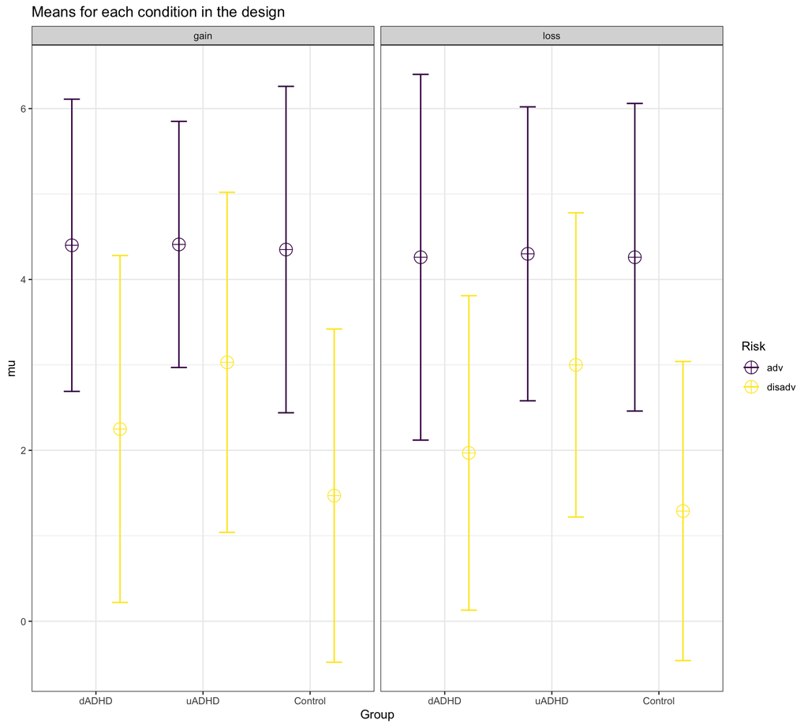

```r
#Plot
H2ab <- ANOVA_design(design = "3b*2w*2w",
                   n = 150,
                   mu = c(4.40,4.26,2.25,1.97,
                            4.41,4.30,3.03,3.00,
                            4.35,4.26,1.47,1.29),
                   sd = c(1.71, 2.14, 2.03, 1.84,
                          1.44, 1.72, 1.99, 1.78,
                          1.91, 1.80, 1.95, 1.75),
                   r = r_matrix,
                   labelnames = c("Group", "dADHD", "uADHD", "Control", "Risk", "adv", "disadv", "Domain", "gain", "loss"),
                   plot = TRUE
)
```

```r
# Run 2000 simulations
H2pwr <- ANOVA_power(H2ab,
                        alpha_level = 0.05,
                        nsims = nsims,
                        verbose = FALSE)
```

Power and Effect sizes for ANOVA tests

| comparison | power | partial_eta_squared | cohen_f | non_centrality |
| --- | --- | --- | --- | --- |
| Group | 99.989406 | 0.0755706 | 0.2859166 | 36.5414973 |
| Risk | 100.000000 | 0.5431648 | 1.0904005 | 531.4710197 |
| Group:Risk | 99.999746 | 0.0966334 | 0.3270631 | 47.8157072 |
| Domain | 51.760927 | 0.0089427 | 0.0949913 | 4.0334360 |
| Group:Domain | 10.519502 | 0.0015406 | 0.0392806 | 0.6897064 |
| Risk:Domain | 6.905939 | 0.0003697 | 0.0192301 | 0.1652995 |
| Group:Risk:Domain | 9.647333 | 0.0013098 | 0.0362153 | 0.5862624 |

Power and Effect sizes for pairwise comparisons (t-tests) - Risk is Disadvantageous

|  | comparison | power | effect_size |
| --- | --- | --- | --- |
| 25 | p_Group_dADHD_Risk_disadv_Domain_gain_Group_uADHD_Risk_disadv_Domain_gain | 92.75 | 0.3919972 |
| 29 | p_Group_dADHD_Risk_disadv_Domain_gain_Group_Control_Risk_disadv_Domain_gain | 91.75 | -0.3938006 |
| 34 | p_Group_dADHD_Risk_disadv_Domain_loss_Group_uADHD_Risk_disadv_Domain_loss | 99.90 | 0.5737889 |
| 38 | p_Group_dADHD_Risk_disadv_Domain_loss_Group_Control_Risk_disadv_Domain_loss | 90.25 | -0.3816766 |
| 55 | p_Group_uADHD_Risk_disadv_Domain_gain_Group_Control_Risk_disadv_Domain_gain | 100.00 | -0.7991423 |
| 60 | p_Group_uADHD_Risk_disadv_Domain_loss_Group_Control_Risk_disadv_Domain_loss | 100.00 | -0.9761770 |

### 6.3 Summary

- Unlike Hypothesis 1, n=28 can only achieve 75% power because for hypothesis once means are changed to reflect a significant difference between dADHD-Control; dADHD-uADHD and uADHD-Control. 80% power is achieved with n=32. However to achieve power for the pairwise comparisons, a sample of 150 per group is needed.
- Once more that is related to the small effect size for the ‘dADHD-Control’ comparison.

# 7. Hypothesis 3

### 7.1. Sample (n=28)

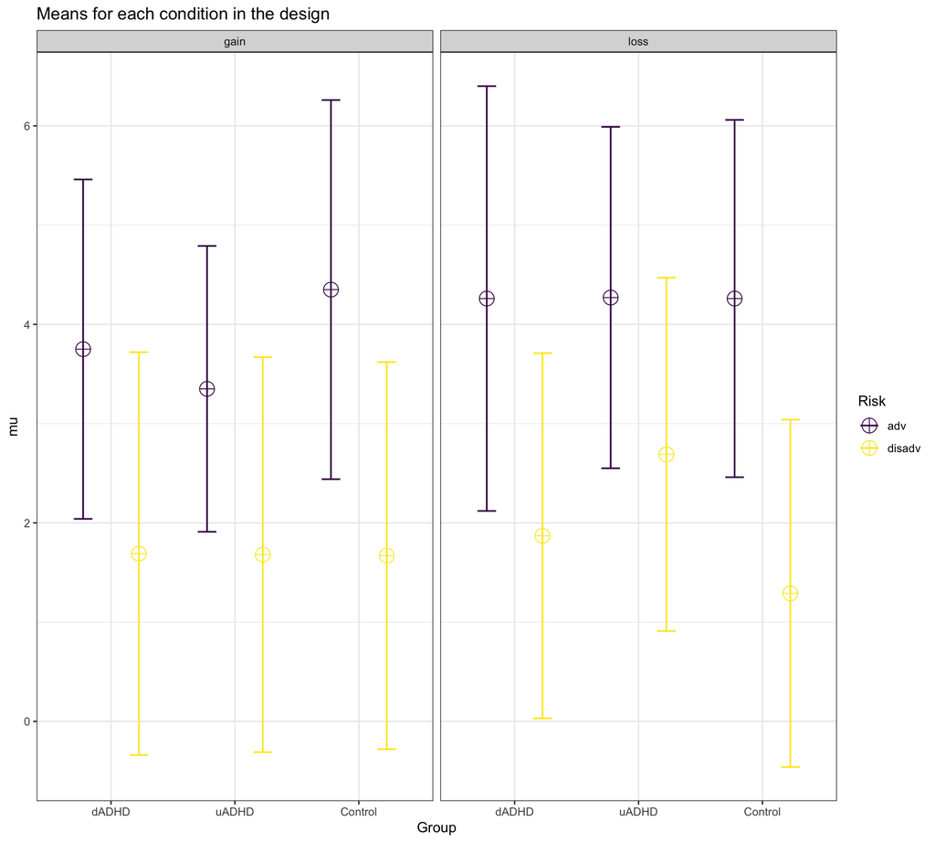

```r
#Plot
H3 <- ANOVA_design(design = "3b*2w*2w",
                   n = 28, #Mixed designs do not allow for different 'n' per group, so I used our lowest number (Diagnosed ADHD)
                   mu = c(3.75,4.26,1.69,1.87,
                          3.35,4.27,1.68,2.69,
                          4.35,4.26,1.67,1.29),
                   sd = c(1.71, 2.14, 2.03, 1.84,
                          1.44, 1.72, 1.99, 1.78,
                          1.91, 1.80, 1.95, 1.75),
                   r = r_matrix,
                   labelnames = c("Group", "dADHD", "uADHD", "Control", "Risk", "adv", "disadv", "Domain", "gain", "loss"),
                   plot = TRUE
)
```

```r
# Run 2000 simulations
H3pwr <- ANOVA_power(H3,
                        alpha_level = 0.05,
                        nsims = nsims,
                        verbose = FALSE)
```

Power and Effect sizes for ANOVA tests

| comparison | power | partial_eta_squared | cohen_f | non_centrality |
| --- | --- | --- | --- | --- |
| Group | 6.032892 | 0.0017347 | 0.0416863 | 0.1407576 |
| Risk | 100.000000 | 0.5647650 | 1.1391265 | 105.1063463 |
| Group:Risk | 49.602572 | 0.0591834 | 0.2508116 | 5.0954219 |
| Domain | 60.296610 | 0.0587086 | 0.2497404 | 5.0519923 |
| Group:Domain | 77.558119 | 0.1044407 | 0.3414976 | 9.4462693 |
| Risk:Domain | 9.408584 | 0.0047333 | 0.0689622 | 0.3852189 |
| Group:Risk:Domain | 8.349011 | 0.0054288 | 0.0738810 | 0.4421310 |

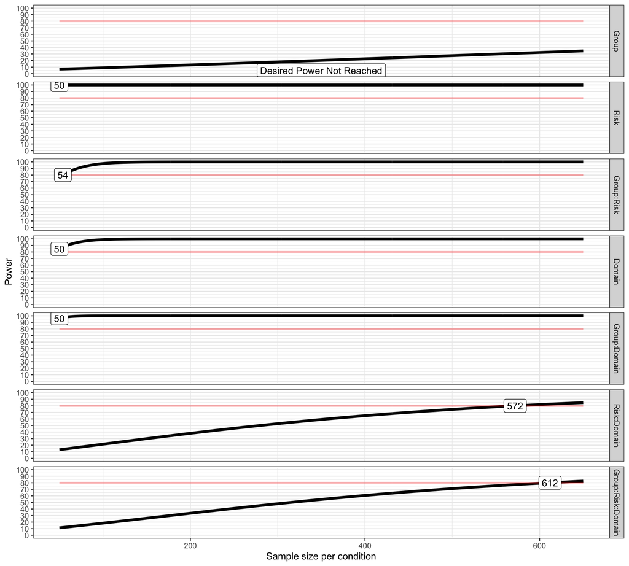

Achieved Power and Sample Size for ANOVA-level effects

| variable | label | n | achieved_power | desired_power |
| --- | --- | --- | --- | --- |
| Group | Desired Power Not Reached | 650 | 34.65539 | 80 |
| Risk | Desired Power Achieved | 50 | 100.00000 | 80 |
| Group:Risk | Desired Power Achieved | 54 | 80.03566 | 80 |
| Domain | Desired Power Achieved | 50 | 84.70648 | 80 |
| Group:Domain | Desired Power Achieved | 50 | 96.22343 | 80 |
| Risk:Domain | Desired Power Achieved | 572 | 80.05883 | 80 |
| Group:Risk:Domain | Desired Power Achieved | 612 | 80.05773 | 80 |

### 7.2. Interim Summary

- Hypothesis 3 gets more complicated. As seen above, to achieve 80% power for the Group:Risk:Domain interaction the sample per group would have to be around n=612. That is not realistic, so below I try a different approach.

### 7.3. Sample (n=160)

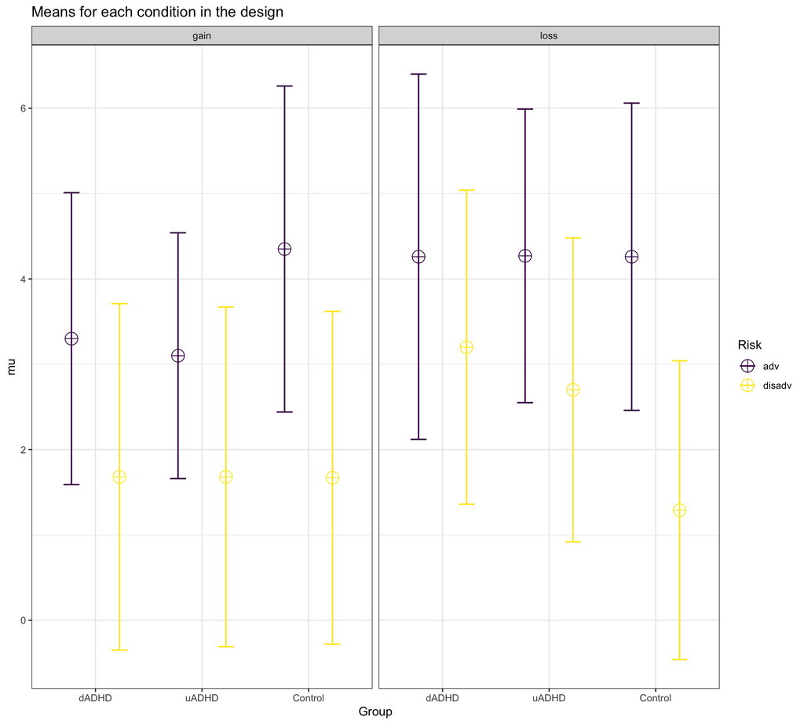

```r
#Plot
H3 <- ANOVA_design(design = "3b*2w*2w",
                   n = 160, #Mixed designs do not allow for different 'n' per group, so I used our lowest number (Diagnosed ADHD)
                   mu = c(3.30,4.26,1.68,3.20,
                          3.10,4.27,1.68,2.70,
                          4.35,4.26,1.67,1.29),
                   sd = c(1.71, 2.14, 2.03, 1.84,
                          1.44, 1.72, 1.99, 1.78,
                          1.91, 1.80, 1.95, 1.75),
                   r = r_matrix,
                   labelnames = c("Group", "dADHD", "uADHD", "Control", "Risk", "adv", "disadv", "Domain", "gain", "loss"),
                   plot = TRUE
)
```

```r
# Run 2000 simulations
H3pwr <- ANOVA_power(H3,
                        alpha_level = 0.05,
                        nsims = nsims,
                        verbose = FALSE)
```

Power and Effect sizes for ANOVA tests

| comparison | power | partial_eta_squared | cohen_f | non_centrality |
| --- | --- | --- | --- | --- |
| Group | 30.87685 | 0.0060117 | 0.0777692 | 2.8849158 |
| Risk | 100.00000 | 0.4751542 | 0.9514838 | 431.8383554 |
| Group:Risk | 99.99997 | 0.1015170 | 0.3361356 | 53.8948707 |
| Domain | 100.00000 | 0.1876228 | 0.4805781 | 110.1656728 |
| Group:Domain | 100.00000 | 0.1719655 | 0.4557182 | 99.0629215 |
| Risk:Domain | 6.29720 | 0.0002365 | 0.0153809 | 0.1128445 |
| Group:Risk:Domain | 80.30288 | 0.0200625 | 0.1430848 | 9.7657499 |

Power and Effect sizes for pairwise comparisons (t-tests) - Risk is Advantageous_Gain Domain

|  | comparison | power | effect_size |
| --- | --- | --- | --- |
| 8 | p_Group_dADHD_Risk_adv_Domain_gain_Group_Control_Risk_adv_Domain_gain | 99.9 | 0.5787318 |
| 42 | p_Group_uADHD_Risk_adv_Domain_gain_Group_Control_Risk_adv_Domain_gain | 100.0 | 0.7413705 |

Power and Effect sizes for pairwise comparisons (t-tests) - Risk is Disadvantageous_Loss Domain

|  | comparison | power | effect_size |
| --- | --- | --- | --- |
| 38 | p_Group_dADHD_Risk_disadv_Domain_loss_Group_Control_Risk_disadv_Domain_loss | 100 | -1.0657173 |
| 60 | p_Group_uADHD_Risk_disadv_Domain_loss_Group_Control_Risk_disadv_Domain_loss | 100 | -0.8022254 |